# SVbyEye: A visual tool to characterize structural variation among whole-genome assemblies

# 6 Visualization of self-alignments

There are cases when one wants to visualize regions that are homologous to each other within a single DNA sequence. Such regions can be reported by the alignment of a given sequence to itself. Such self-alignments are typical for SDs that are paralogous sequences with high sequence identity.

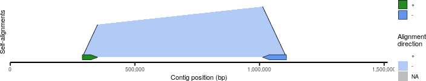

```r
## Get PAF to plot
paf.file <- system.file("extdata", "test2.paf", package = "SVbyEye")
## Read in PAF
paf.table <- readPaf(
    paf.file = paf.file, include.paf.tags = TRUE,
    restrict.paf.tags = "cg"
)
## Make a plot
## Plot alignment as horizontal dotplots and color by alignment directionality
plotSelf(paf.table = paf.table, color.by = "direction", shape = "segment")
```

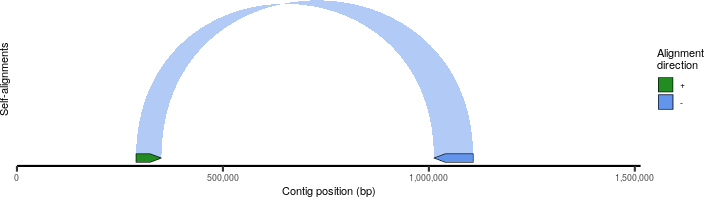

```r
## Plot alignment as arcs and color by alignment directionality
plotSelf(paf.table = paf.table, color.by = "direction", shape = "arc")
```

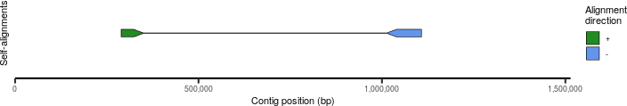

```r
## Plot alignment as arrows and color by alignment directionality
plotSelf(paf.table = paf.table, color.by = "direction", shape = "arrow")
```

Again, some of the previously mentioned parameters apply also to self-alignments. For example, users can define the color palette and bin the alignments as well as break alignments at the insertions and deletions.

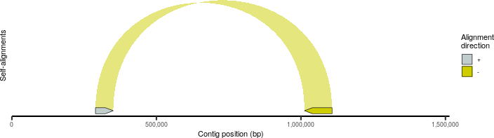

```r
## Plot alignment as arcs and color by alignment directionality
plotSelf(
    paf.table = paf.table, color.by = "direction", shape = "arc",
    color.palette = c("+" = "azure3", "-" = "yellow3")
)
```

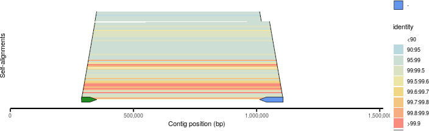

```r
## Bin PAF alignments into user-defined bin and color them by sequence identity
plotSelf(paf.table = paf.table, binsize = 1000)
```

When breaking the self-alignments at insertions and deletions, proximal duplication is considered as a query and the distal duplication as a target. It means that sequence missing in the query is considered a deletion and sequence inserted in the query with respect to target sequence is considered an insertion.

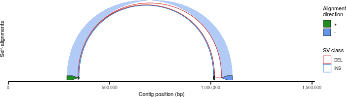

```r
## Highlight structural variants within self-alignments
plotSelf(
    paf.table = paf.table, min.deletion.size = 50, min.insertion.size = 50,
    highlight.sv = "outline", shape = "arc"
)
```

Of course more complex self-alignments can be visualized as well in order to gain an overview of all pairs of SDs that can facilitate rearrangements between them.

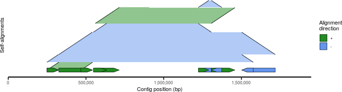

```r
## Get PAF to plot
paf.file <- system.file("extdata", "test5.paf", package = "SVbyEye")
## Read in PAF
paf.table <- readPaf(paf.file = paf.file)
## Make a plot
## Plot alignment as horizontal dotplots and color by alignment directionality
plotSelf(paf.table = paf.table, color.by = "direction", shape = "segment")
```

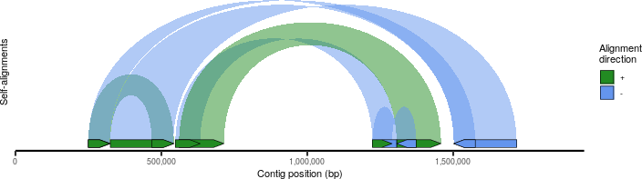

```r
## Plot alignment as arcs and color by alignment directionality
plotSelf(paf.table = paf.table, color.by = "direction", shape = "arc")
```

# 7 Visualization of whole-genome alignments

Lastly, SVbyEye allows plotting an overview of a whole-genome assembly or selected chromosomes with respect to a reference using the `plotGenome()` function. With this function whole-genome alignments can be visualized to observe large structural rearrangements with respect to a single reference.

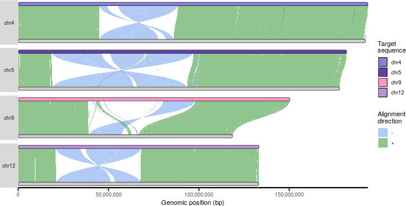

```r
## Get PAF to plot ##
paf.file <- system.file("extdata", "PTR_test.paf", package = "SVbyEye")
## Read in PAF
paf.table <- readPaf(paf.file = paf.file)
## Make a plot ##
## Color by alignment directionality
plotGenome(
    paf.table = paf.table, chromosomes = paste0("chr", c(4, 5, 9, 12)),
    chromosome.bar.width = grid::unit(2, "mm"),
    min.query.aligned.bp = 5000000
)
```

# 8 Modifying SVbyEye plots

Conveniently, SVbyEye reports all plots as ‘ggplot2’ class objects that can be further modified using other ggplot2 specific functions and themes in order to change the overall appearance of the plot.

## 8.1 Usage of ggplot2 plotting functions and themes

There are a number of ggplot2 functions and plotting themes from other packages that can be applied to SVbyEye plots. This of course has some limitations, meaning that not every ggplot2 function will work or generate a sensible output.

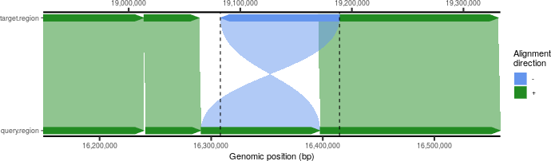

```r
## Get PAF to plot ##
paf.file <- system.file("extdata", "test1.paf", package = "SVbyEye")
## Read in PAF
paf.table <- readPaf(paf.file = paf.file)
## Make a plot
plt <- plotMiro(paf.table = paf.table, color.by = "direction")
## Apply ggplot2 function
## Here adding dashed vertical lines to the plot
## Be aware that x-axis is reported in target coordinates
plt + ggplot2::geom_vline(xintercept = c(19082149, 19188924), linetype='dashed')
```

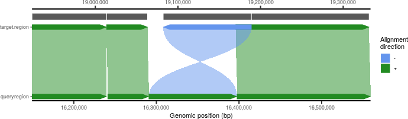

```r
## Adding extra rectangles to the plot
plt + ggplot2::geom_rect(data = paf.table,
                         ggplot2::aes(xmin=t.start, xmax=t.end, ymin=2.1, ymax=2.2),
                         color='white')
```

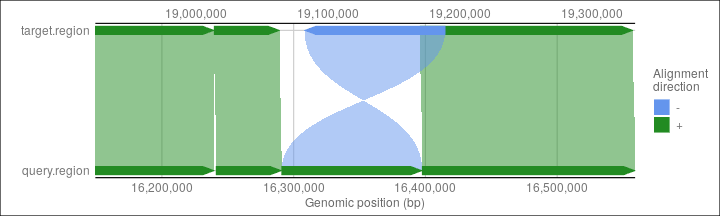

```r
## Apply a predefined theme from the ggthemes package
plt + ggthemes::theme_gdocs()
```

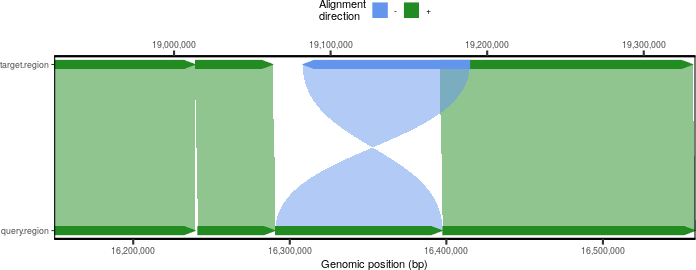

```r
## Apply a user defined theme adjustments
## Here adding black border around the plot with legend on the top
plt + ggplot2::theme(panel.border = ggplot2::element_rect(color = "black",
                                                          fill=NA, linewidth=1),
                     legend.position = 'top')
```

## 8.2 Adjusting default color schemes

SVbyEye has its own default color scheme to color alignments by their direction as well as their sequence identity. However, these default color schemes can be changed either by setting your own color for alignment direction as explained in the section Visualization of sequence-to-sequence alignments. In case of changing the color scheme for sequence identity, a user will have to define an own discrete variable along with corresponding color scheme in order to change the default. The process of how to do this is explained below.

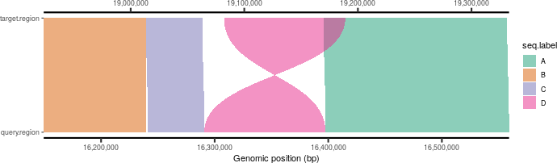

```r
library(RColorBrewer)
## Get PAF to plot ##
paf.file <- system.file("extdata", "test1.paf", package = "SVbyEye")
## Read in PAF
paf.table <- readPaf(paf.file = paf.file)
## Define a new column to be used to define colors
paf.table$seq.label <- LETTERS[1:4]
## Define color using a common plotting scheme
colors <- setNames(RColorBrewer::brewer.pal(n = 4, name = 'Dark2'),
                   paf.table$seq.label)
## Make a plot
plotMiro(paf.table = paf.table, color.by = 'seq.label',
         color.palette = colors, add.alignment.arrows = FALSE)
```

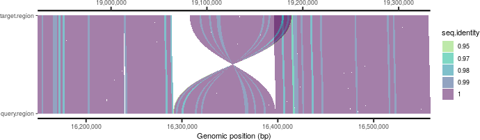

```r
## Bin the alignments into user defined bins
paf.table.binned <- pafToBins(paf.table = paf.table, binsize = 2000)
## Define a new column to be used to define colors (must be discrete value)
paf.table.binned$seq.identity  <- as.character(round(paf.table.binned$n.match /
                                                     paf.table.binned$aln.len,
                                                     digits = 2))
## Define discrete color levels
seq.idt <- sort(unique(paf.table.binned$seq.identity), decreasing = TRUE)
## Define color using a common plotting scheme
colors <- setNames(grDevices::hcl.colors(n = 6, palette = 'Viridis'), seq.idt)
## Make a plot
plotMiro(paf.table = paf.table.binned, color.by = 'seq.identity',
         color.palette = colors, add.alignment.arrows = FALSE)
```

# 9 References

Deamer, David W, and Daniel Branton. 2002. “Characterization of Nucleic Acids by Nanopore Analysis.” *Acc. Chem. Res.* 35 (10): 817–25.

Li, Heng. 2016. “Minimap and Miniasm: Fast Mapping and de Novo Assembly for Noisy Long Sequences.” *Bioinformatics* 32 (14): 2103–10.

Parsons, J D. 1995. “Miropeats: Graphical DNA Sequence Comparisons.” *Bioinformatics* 11 (6): 615–19.

Wenger, Aaron M, Paul Peluso, William J Rowell, Pi-Chuan Chang, Richard J Hall, Gregory T Concepcion, Jana Ebler, et al. 2019. “Accurate Circular Consensus Long-Read Sequencing Improves Variant Detection and Assembly of a Human Genome.” *Nat. Biotechnol.* 37 (10): 1155–62.

Wickham, Hadley. 2016. *Ggplot2: Elegant Graphics for Data Analysis*. Springer-Verlag New York. https://ggplot2.tidyverse.org.